# Part I - Ford GoBike System Data:

## by Ford GoBike System Data

## Introduction

> This data set includes information about individual rides made in a bike-sharing system covering the greater San Francisco Bay area.

## Preliminary Wrangling

```python
# import all packages and set plots to be embedded inline
import numpy as np
import pandas as pd
import matplotlib.pyplot as plt
import seaborn as sb
import json
%matplotlib inline
```

```python
#load dataset
data = pd.read_csv('201902-fordgobike-tripdata.csv')
data.head(10)
```

|  | duration_sec | start_time | end_time | start_station_id | start_station_name | start_station_latitude | start_station_longitude | end_station_id | end_station_name | end_station_latitude | end_station_longitude | bike_id | user_type | member_birth_year | member_gender | bike_share_for_all_trip |
| --- | --- | --- | --- | --- | --- | --- | --- | --- | --- | --- | --- | --- | --- | --- | --- | --- |
| 0 | 52185 | 2019-02-28 17:32:10.1450 | 2019-03-01 08:01:55.9750 | 21.0 | Montgomery St BART Station (Market St at 2nd St) | 37.789625 | -122.400811 | 13.0 | Commercial St at Montgomery St | 37.794231 | -122.402923 | 4902 | Customer | 1984.0 | Male | No |
| 1 | 42521 | 2019-02-28 18:53:21.7890 | 2019-03-01 06:42:03.0560 | 23.0 | The Embarcadero at Steuart St | 37.791464 | -122.391034 | 81.0 | Berry St at 4th St | 37.775880 | -122.393170 | 2535 | Customer | NaN | NaN | No |
| 2 | 61854 | 2019-02-28 12:13:13.2180 | 2019-03-01 05:24:08.1460 | 86.0 | Market St at Dolores St | 37.769305 | -122.426826 | 3.0 | Powell St BART Station (Market St at 4th St) | 37.786375 | -122.404904 | 5905 | Customer | 1972.0 | Male | No |
| 3 | 36490 | 2019-02-28 17:54:26.0100 | 2019-03-01 04:02:36.8420 | 375.0 | Grove St at Masonic Ave | 37.774836 | -122.446546 | 70.0 | Central Ave at Fell St | 37.773311 | -122.444293 | 6638 | Subscriber | 1989.0 | Other | No |
| 4 | 1585 | 2019-02-28 23:54:18.5490 | 2019-03-01 00:20:44.0740 | 7.0 | Frank H Ogawa Plaza | 37.804562 | -122.271738 | 222.0 | 10th Ave at E 15th St | 37.792714 | -122.248780 | 4898 | Subscriber | 1974.0 | Male | Yes |
| 5 | 1793 | 2019-02-28 23:49:58.6320 | 2019-03-01 00:19:51.7600 | 93.0 | 4th St at Mission Bay Blvd S | 37.770407 | -122.391198 | 323.0 | Broadway at Kearny | 37.798014 | -122.405950 | 5200 | Subscriber | 1959.0 | Male | No |
| 6 | 1147 | 2019-02-28 23:55:35.1040 | 2019-03-01 00:14:42.5880 | 300.0 | Palm St at Willow St | 37.317298 | -121.884995 | 312.0 | San Jose Diridon Station | 37.329732 | -121.901782 | 3803 | Subscriber | 1983.0 | Female | No |
| 7 | 1615 | 2019-02-28 23:41:06.7660 | 2019-03-01 00:08:02.7560 | 10.0 | Washington St at Kearny St | 37.795393 | -122.404770 | 127.0 | Valencia St at 21st St | 37.756708 | -122.421025 | 6329 | Subscriber | 1989.0 | Male | No |
| 8 | 1570 | 2019-02-28 23:41:48.7900 | 2019-03-01 00:07:59.7150 | 10.0 | Washington St at Kearny St | 37.795393 | -122.404770 | 127.0 | Valencia St at 21st St | 37.756708 | -122.421025 | 6548 | Subscriber | 1988.0 | Other | No |
| 9 | 1049 | 2019-02-28 23:49:47.6990 | 2019-03-01 00:07:17.0250 | 19.0 | Post St at Kearny St | 37.788975 | -122.403452 | 121.0 | Mission Playground | 37.759210 | -122.421339 | 6488 | Subscriber | 1992.0 | Male | No |

```python
# check shape data
data.shape
```

```
(183412, 16)
```

```python
#check datainfo
data.info()
```

```
<class 'pandas.core.frame.DataFrame'>
RangeIndex: 183412 entries, 0 to 183411
Data columns (total 16 columns):
duration_sec               183412 non-null int64
start_time                 183412 non-null object
end_time                   183412 non-null object
start_station_id           183215 non-null float64
start_station_name         183215 non-null object
start_station_latitude     183412 non-null float64
start_station_longitude    183412 non-null float64
end_station_id             183215 non-null float64
end_station_name           183215 non-null object
end_station_latitude       183412 non-null float64
end_station_longitude      183412 non-null float64
bike_id                    183412 non-null int64
user_type                  183412 non-null object
member_birth_year          175147 non-null float64
member_gender              175147 non-null object
bike_share_for_all_trip    183412 non-null object
dtypes: float64(7), int64(2), object(7)
memory usage: 22.4+ MB
```

```python
# dropna col 'start_station_id', 'start_station_name', 'end_station_id','end_station_name'
data.dropna(subset=['start_station_id', 'start_station_name', 'end_station_id','end_station_name'],inplace = True)
```

```python
#reset index after dropna
data.reset_index(inplace = True)
```

```python
# change type data start time to datetime
data['start_time'] = pd.to_datetime(data['start_time'])
```

```python
# change type data end time to datetime
data['end_time'] = pd.to_datetime(data['end_time'])
```

```python
# change type data start station id to int
data.start_station_id = data.start_station_id.astype(int)
```

```python
# change type data end station id to int
data.end_station_id = data.end_station_id.astype(int)
```

```python
# check data infor again
data.info()
```

```
<class 'pandas.core.frame.DataFrame'>
RangeIndex: 183215 entries, 0 to 183214
Data columns (total 17 columns):
index                      183215 non-null int64
duration_sec               183215 non-null int64
start_time                 183215 non-null datetime64[ns]
end_time                   183215 non-null datetime64[ns]
start_station_id           183215 non-null int64
start_station_name         183215 non-null object
start_station_latitude     183215 non-null float64
start_station_longitude    183215 non-null float64
end_station_id             183215 non-null int64
end_station_name           183215 non-null object
end_station_latitude       183215 non-null float64
end_station_longitude      183215 non-null float64
bike_id                    183215 non-null int64
user_type                  183215 non-null object
member_birth_year          174952 non-null float64
member_gender              174952 non-null object
bike_share_for_all_trip    183215 non-null object
dtypes: datetime64[ns](2), float64(5), int64(5), object(5)
memory usage: 23.8+ MB
```

```python
# data describe() for 'duration_sec', 'start_station_id', 'start_station_latitude', 'start_station_longitude', 'end_station_id' ,'end_station_latitude', 'end_station_longitude'
data[['duration_sec', 'start_station_id', 'start_station_latitude', 'start_station_longitude', 'end_station_id' ,'end_station_latitude', 'end_station_longitude']].describe()
```

|  | duration_sec | start_station_id | start_station_latitude | start_station_longitude | end_station_id | end_station_latitude | end_station_longitude |
| --- | --- | --- | --- | --- | --- | --- | --- |
| count | 183215.000000 | 183215.000000 | 183215.000000 | 183215.000000 | 183215.000000 | 183215.000000 | 183215.000000 |
| mean | 725.902017 | 138.590427 | 37.771615 | -122.353104 | 136.249123 | 37.771820 | -122.352689 |
| std | 1795.078654 | 111.778864 | 0.098914 | 0.116387 | 111.515131 | 0.098819 | 0.115961 |
| min | 61.000000 | 3.000000 | 37.317298 | -122.453704 | 3.000000 | 37.317298 | -122.453704 |
| 25% | 325.000000 | 47.000000 | 37.770407 | -122.412408 | 44.000000 | 37.770407 | -122.411726 |
| 50% | 514.000000 | 104.000000 | 37.780760 | -122.398285 | 100.000000 | 37.781010 | -122.398279 |
| 75% | 796.000000 | 239.000000 | 37.797280 | -122.287180 | 235.000000 | 37.797320 | -122.288665 |
| max | 85444.000000 | 398.000000 | 37.880222 | -121.874119 | 398.000000 | 37.880222 | -121.874119 |

```python
# check some record after Wrangling
data.head()
```

|  | index | duration_sec | start_time | end_time | start_station_id | start_station_name | start_station_latitude | start_station_longitude | end_station_id | end_station_name | end_station_latitude | end_station_longitude | bike_id | user_type | member_birth_year | member_gender | bike_share_for_all_trip |
| --- | --- | --- | --- | --- | --- | --- | --- | --- | --- | --- | --- | --- | --- | --- | --- | --- | --- |
| 0 | 0 | 52185 | 2019-02-28 17:32:10.145 | 2019-03-01 08:01:55.975 | 21 | Montgomery St BART Station (Market St at 2nd St) | 37.789625 | -122.400811 | 13 | Commercial St at Montgomery St | 37.794231 | -122.402923 | 4902 | Customer | 1984.0 | Male | No |
| 1 | 1 | 42521 | 2019-02-28 18:53:21.789 | 2019-03-01 06:42:03.056 | 23 | The Embarcadero at Steuart St | 37.791464 | -122.391034 | 81 | Berry St at 4th St | 37.775880 | -122.393170 | 2535 | Customer | NaN | NaN | No |
| 2 | 2 | 61854 | 2019-02-28 12:13:13.218 | 2019-03-01 05:24:08.146 | 86 | Market St at Dolores St | 37.769305 | -122.426826 | 3 | Powell St BART Station (Market St at 4th St) | 37.786375 | -122.404904 | 5905 | Customer | 1972.0 | Male | No |
| 3 | 3 | 36490 | 2019-02-28 17:54:26.010 | 2019-03-01 04:02:36.842 | 375 | Grove St at Masonic Ave | 37.774836 | -122.446546 | 70 | Central Ave at Fell St | 37.773311 | -122.444293 | 6638 | Subscriber | 1989.0 | Other | No |
| 4 | 4 | 1585 | 2019-02-28 23:54:18.549 | 2019-03-01 00:20:44.074 | 7 | Frank H Ogawa Plaza | 37.804562 | -122.271738 | 222 | 10th Ave at E 15th St | 37.792714 | -122.248780 | 4898 | Subscriber | 1974.0 | Male | Yes |

```python
#check it is error
data[data.duration_sec == 85444]
```

|  | index | duration_sec | start_time | end_time | start_station_id | start_station_name | start_station_latitude | start_station_longitude | end_station_id | end_station_name | end_station_latitude | end_station_longitude | bike_id | user_type | member_birth_year | member_gender | bike_share_for_all_trip |
| --- | --- | --- | --- | --- | --- | --- | --- | --- | --- | --- | --- | --- | --- | --- | --- | --- | --- |
| 101231 | 101361 | 85444 | 2019-02-13 17:59:55.124 | 2019-02-14 17:43:59.954 | 5 | Powell St BART Station (Market St at 5th St) | 37.783899 | -122.408445 | 98 | Valencia St at 16th St | 37.765052 | -122.421866 | 6168 | Subscriber | NaN | NaN | No |

### What is the structure of your dataset?

> the structure of my dataset is CSV file

### What is/are the main feature(s) of interest in your dataset?

> Average speed of trips

> Average time to complete the trip

> Locations that are usually caught

### What features in the dataset do you think will help support your investigation into your feature(s) of interest?

> duration_sec, start_station_latitude, start_station_longitude, end_station_latitude, end_station_longitude, start_station_id, end_station_id

## Univariate Exploration

#### Duration_sec

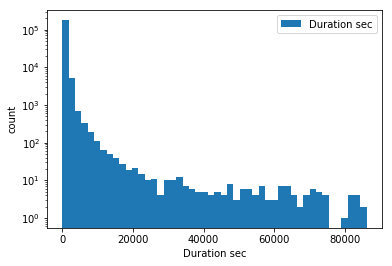

```python
# hist plot for duration sec
bins = np.arange(0, data.duration_sec.max()+1795, 1795)
plt.hist(x = 'duration_sec', data= data, bins=bins, log = True, label = 'Duration sec')
plt.xlabel('Duration sec')
plt.ylabel('count')
plt.legend()
```

#### start_station_id

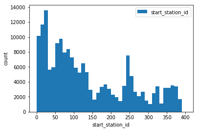

```python
# hist plot of start_station_id
bins = np.arange(0, data.start_station_id.max()+10, 10)
plt.hist(x ="start_station_id", data= data, bins= bins, label = 'start_station_id')
plt.xlabel('start_station_id')
plt.ylabel('count')
plt.legend()
```

Observation 2:

- the starting positions are mostly positions from 0 to 140
- in particular, there is a spike in positions from 230 to 260, from 315 to 375

#### end_station_id

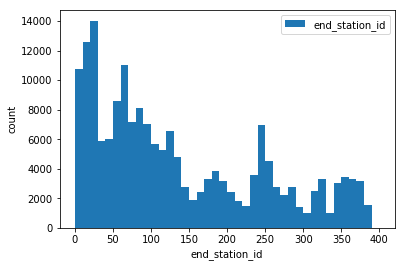

```python
# hist plot of start_station_id
bins = np.arange(0, data.end_station_id.max()+10, 10)
plt.hist(x ="end_station_id", data= data, bins= bins, label = 'end_station_id')
plt.xlabel('end_station_id')
plt.ylabel('count')
plt.legend()
```

Observation 3:

- the starting positions are mostly positions from 0 to 140
- in particular, there is a spike in positions from 240 to 260

#### start_station_latitude

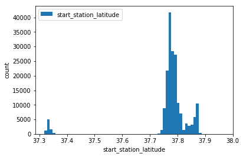

```python
# hist plot of start_station_latitude
bins = np.arange(data.start_station_latitude.min(), data.start_station_latitude.max()+0.09, 0.01)
plt.hist(x ="start_station_latitude", data= data, bins= bins, label = 'start_station_latitude')
plt.xlabel('start_station_latitude')
plt.ylabel('count')
plt.legend()
```

Observation 4:

- the starting station latitude fluctuates quite low, from 37.3 to 37.9

#### start_station_longitude

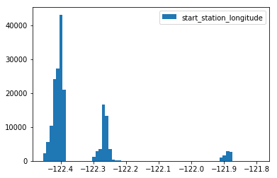

```python
# hist plot of start_station_longitude
bins = np.arange(data.start_station_longitude.min(), data.start_station_longitude.max()+0.09, 0.01)
plt.hist(x ="start_station_longitude", data= data, bins= bins, label = 'start_station_longitude')
plt.legend()
```

Observation 5:

- The starting point's longitude also fluctuates low, the distance between the two largest and smallest points is only ~0.6

#### end_station_latitude

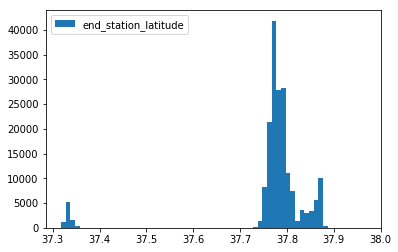

```python
# hist plot of end_station_latitude
bins = np.arange(data.end_station_latitude.min(), data.end_station_latitude.max()+0.09, 0.01)
plt.hist(x ="end_station_latitude", data= data, bins= bins, label = 'end_station_latitude')
plt.legend()
```

Observation 5:

- the distribution of the data is very similar to the start_station_latitude plot

#### end_station_longitude

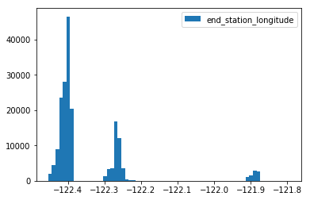

```python
# hist plot of end_station_longitude
bins = np.arange(data.end_station_longitude.min(), data.end_station_longitude.max()+0.09, 0.01)
plt.hist(x ="end_station_longitude", data= data, bins= bins, label = 'end_station_longitude')
plt.legend()
```

### Discuss the distribution(s) of your variable(s) of interest. Were there any unusual points? Did you need to perform any transformations?

> The duration of each trip is quite short from 0-1000s and usually only departs and arrives at places with id from 0-140. especially, the position with id from 230-260 has the number of going to many mutations. i think it need not to perform any transformations.

### Of the features you investigated, were there any unusual distributions? Did you perform any operations on the data to tidy, adjust, or change the form of the data? If so, why did you do this?

> I think this distribution is normal, so I won't do anything on this data structure

## Bivariate Exploration

#### coordinates of the starting point

```
Text(0,0.5,'longitude')
```

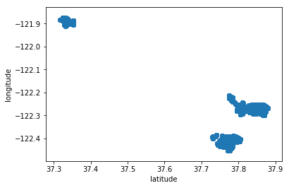

```python
#scatter plot of coordinates of the starting point
plt.scatter(data = data, x = 'start_station_latitude', y = 'start_station_longitude');
plt.xlabel('latitude')
plt.ylabel('longitude')
```

```
Text(0,0.5,'longitude')
```

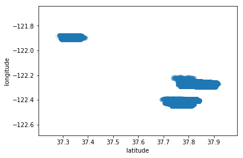

```python
# reg plot of coordinates of the starting point
sb.regplot(data = data, x = 'start_station_latitude', y = 'start_station_longitude', x_jitter=0.04, scatter_kws={'alpha':1/10}, fit_reg=False);
plt.xlabel('latitude')
plt.ylabel('longitude')
```

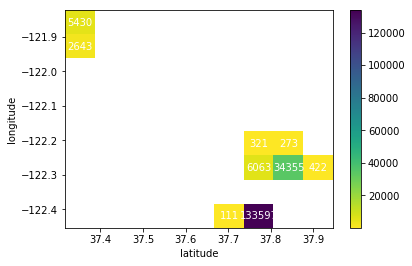

```python
# heatmap of coordinates of the starting point
bins_x = np.arange(data.start_station_latitude.min(), data.start_station_latitude.max()+0.09, 0.07)
bins_y = np.arange(data.start_station_longitude.min(), data.start_station_longitude.max()+0.09, 0.07)

h2d = plt.hist2d(data = data, x = 'start_station_latitude', y = 'start_station_longitude',cmin=0.5, cmap='viridis_r', bins = [bins_x, bins_y]);

plt.colorbar()
plt.xlabel('latitude')
plt.ylabel('longitude')

counts = h2d[0]

# Add text annotation on each cell
# Loop through the cell counts and add text annotations for each
for i in range(counts.shape[0]):
    for j in range(counts.shape[1]):
        c = counts[i,j]
        if c >= 100: # increase visibility on darker cells
            plt.text(bins_x[i]+0.035, bins_y[j]+0.035, int(c),
                     ha = 'center', va = 'center', color = 'white')
        elif c > 0:
            plt.text(bins_x[i]+0.035, bins_y[j]+0.035, int(c),
                     ha = 'center', va = 'center', color = 'black')
```

Observation 1:

- The starting position has the highest concentration at the position with x coordinates from about 37.7 to 37.8, y coordinates from about -122.5 to about -122.4.
- The starting position has the second highest concentration at the position with x coordinates from about 37.8 to 37.9, y coordinates from about -122.25 to about -122.3.

#### coordinates of the end point

```
Text(0,0.5,'longitude')
```

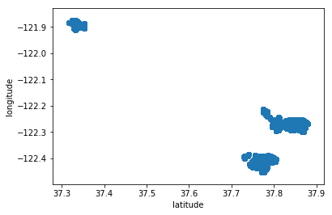

```python
#scatter plot of coordinates of the end point
plt.scatter(data = data, x = 'end_station_latitude', y = 'end_station_longitude');
plt.xlabel('latitude')
plt.ylabel('longitude')
```

```
Text(0,0.5,'longitude')
```

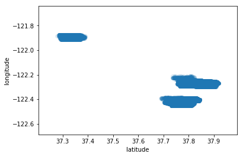

```python
#regplot of coordinates of the end point
sb.regplot(data = data, x = 'end_station_latitude', y = 'end_station_longitude', x_jitter=0.04, scatter_kws={'alpha':1/10}, fit_reg=False);
plt.xlabel('latitude')
plt.ylabel('longitude')
```

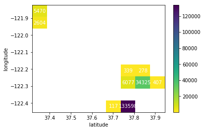

```python
# heatmap of coordinates of the end point
bins_x = np.arange(data.end_station_latitude.min(), data.end_station_latitude.max()+0.09, 0.07)
bins_y = np.arange(data.end_station_longitude.min(), data.end_station_longitude.max()+0.09, 0.07)

h2d = plt.hist2d(data = data, x = 'end_station_latitude', y = 'end_station_longitude',cmin=0.5, cmap='viridis_r', bins = [bins_x, bins_y]);

plt.colorbar()
plt.xlabel('latitude')
plt.ylabel('longitude')

counts = h2d[0]

# Add text annotation on each cell
# Loop through the cell counts and add text annotations for each
for i in range(counts.shape[0]):
    for j in range(counts.shape[1]):
        c = counts[i,j]
        if c >= 100: # increase visibility on darker cells
            plt.text(bins_x[i]+0.035, bins_y[j]+0.035, int(c),
                     ha = 'center', va = 'center', color = 'white')
        elif c > 0:
            plt.text(bins_x[i]+0.035, bins_y[j]+0.035, int(c),
                     ha = 'center', va = 'center', color = 'black')
```

Observation 2:

- The coordinates at the end position have the same dispersion as the coordinates at the starting position
- The starting position has the highest concentration at the position with x coordinates from about 37.7 to 37.8, y coordinates from about -122.5 to about -122.4.
- The starting position has the second highest concentration at the position with x coordinates from about 37.8 to 37.9, y coordinates from about -122.25 to about -122.3.

#### relationship between start_station_id and end_station_id

```
Text(0,0.5,'end_station_id')
```

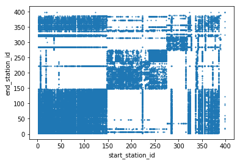

```python
# scatter plot of relationship between start_station_id and end_station_id
plt.scatter(data=data, x='start_station_id', y='end_station_id', s=1)

plt.xlabel('start_station_id')
plt.ylabel('end_station_id')
```

```
Text(0,0.5,'end_station_id')
```

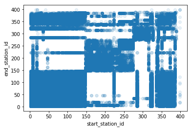

```python
# regplot of relationship between start_station_id and end_station_id
sb.regplot(data = data, x = 'start_station_id', y = 'end_station_id', x_jitter=0.04, scatter_kws={'alpha':1/10}, fit_reg=False);

plt.xlabel('start_station_id')
plt.ylabel('end_station_id')
```

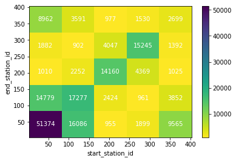

```python
# heatmap of relationship between start_station_id and end_station_id
bins_x = np.arange(data.start_station_id.min(), data.start_station_id.max()+80, 80)
bins_y = np.arange(data.end_station_id.min(), data.end_station_id.max()+80, 80)

h2d = plt.hist2d(data = data, x = 'start_station_id', y = 'end_station_id',cmin=0.5, cmap='viridis_r', bins = [bins_x, bins_y]);

plt.colorbar()
plt.xlabel('start_station_id')
plt.ylabel('end_station_id')

counts = h2d[0]

# Add text annotation on each cell
# Loop through the cell counts and add text annotations for each
for i in range(counts.shape[0]):
    for j in range(counts.shape[1]):
        c = counts[i,j]
        if c >= 100: # increase visibility on darker cells
            plt.text(bins_x[i]+40, bins_y[j]+40, int(c),
                     ha = 'center', va = 'center', color = 'white')
        elif c > 0:
            plt.text(bins_x[i]+40, bins_y[j]+40, int(c),
                     ha = 'center', va = 'center', color = 'black')
```

Observation 3:

- Trips usually start in the range start_station_id 0 to 160 and arrive in the range end_station_id 0 to 160

### Talk about some of the relationships you observed in this part of the investigation. How did the feature(s) of interest vary with other features in the dataset?

> regular trips to and from a location with latitude from 37.7 to 37.8 , longitude from -122.5 to -122.4

> trips usually start from a location with an ID between 0 and 150 and arrive at a location with an ID between 0 and 150

## Multivariate Exploration

> Create plots of three or more variables to investigate your data even further. Make sure that your investigations are justified, and follow from your work in the previous sections.

```python
# get data start station
df_start = pd.DataFrame(columns=['latitude','longitude','id','name'])
df_start[['latitude','longitude','id','name']] = data[['start_station_latitude','start_station_longitude','start_station_id','start_station_name']]
df_start['type'] = 'start'

# get data end station
df_end = pd.DataFrame(columns=['latitude','longitude','id','name'])
df_end [['latitude','longitude','id','name']] = data[['end_station_latitude','end_station_longitude','end_station_id','end_station_name']]
df_end ['type'] = 'end'

# create a dataframe summarizing all start and end station
frames = [df_start, df_end]
df_coordinates = pd.concat(frames)
df_coordinates.head()
```

|  | latitude | longitude | id | name | type |
| --- | --- | --- | --- | --- | --- |
| 0 | 37.789625 | -122.400811 | 21 | Montgomery St BART Station (Market St at 2nd St) | start |
| 1 | 37.791464 | -122.391034 | 23 | The Embarcadero at Steuart St | start |
| 2 | 37.769305 | -122.426826 | 86 | Market St at Dolores St | start |
| 3 | 37.774836 | -122.446546 | 375 | Grove St at Masonic Ave | start |
| 4 | 37.804562 | -122.271738 | 7 | Frank H Ogawa Plaza | start |

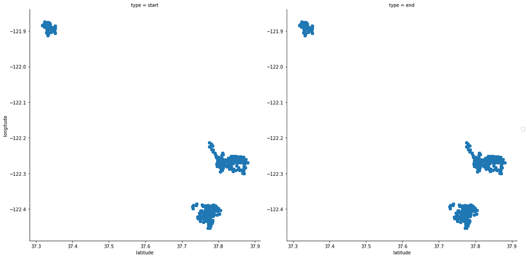

```python
# create a plot to compare the start station and the end station
g = sb.FacetGrid(data = df_coordinates, col = 'type', size =8)
g.map(plt.scatter, 'latitude','longitude')
g.add_legend()
```

Observation 1:

- the coordinates of the start_station and the end_station actually coincide, and have almost the same density

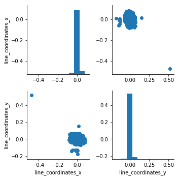

```python
# get x coordinate of the line segment
data['line_coordinates_x'] = data['end_station_latitude'] - data['start_station_latitude']
# get y coordinate of the line segment
data['line_coordinates_y'] = data['end_station_longitude'] - data['start_station_longitude']

# plot of relationship between trips
g = sb.PairGrid(data = data, vars = ['line_coordinates_x', 'line_coordinates_y'])
g.map_diag(plt.hist)
g.map_offdiag(plt.scatter)
```

```python
# get distance of trip
import math
data['distance'] = data['line_coordinates_x']**2 + data['line_coordinates_y']**2
data['distance'] = data['distance'].apply(np.sqrt)
```

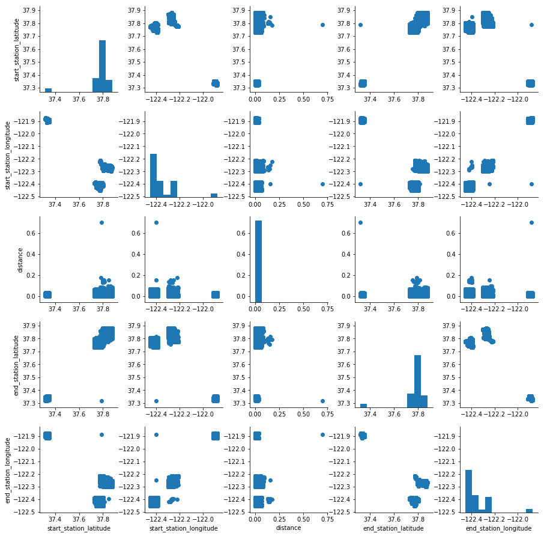

```python
# plot of relationship between 'start_station_latitude','start_station_longitude','distance','end_station_latitude','end_station_longitude'
g = sb.PairGrid(data = data, vars = ['start_station_latitude','start_station_longitude','distance','end_station_latitude','end_station_longitude'])
g.map_diag(plt.hist)
g.map_offdiag(plt.scatter)
```

Observation 2:

- short distance from start and end point

### Talk about some of the relationships you observed in this part of the investigation. Were there features that strengthened each other in terms of looking at your feature(s) of interest?

> Our initial assumptions have been reinforced. the trips have quite short distances, try only going at certain coordinates

### Were there any interesting or surprising interactions between features?

> nothing

## Conclusions

> the trips have quite short distances, try only going at certain coordinates. the coordinates of the start_station and the end_station actually coincide, and have almost the same density